# Plotting Baseball Statistics using R: Queing an SQL Database

[Ian Ruginski](http://www.psych.utah.edu/ianruginski)

December 5, 2015

## Introduction

This tutorial will help you link R to a locally hosted SQL database, create new variables in R from that database, and plot in R using SQL data. Social scientists please note that you can implement this code with *any* type of data that you would like to work with in R but exceeds the memory storage capacity of the R workspace. This is a great technique for analyzing large sample size datasets with R.

**Steps needed prior to running code below:**

1. Install [MySQL](http://dev.mysql.com/downloads/mysql/). This will allow to to locally host a database.
2. Install some type of SQL GUI if desired (personally, I prefer [SQLyog](https://github.com/webyog/sqlyog-community/wiki/Downloads)).
3. Download [Sean Lahman’s baseball database](http://www.seanlahman.com/baseball-archive/statistics/) and load it into SQL.

```r
##this calls the packages required. use install.packages('RMySQL') if not installed
library(RMySQL)
library(lattice)
```

```r
con <- dbConnect(MySQL(),
user = 'username', #replace this with your SQL username
password = 'password', #replace this with your SQL password
host = 'localhost', #replace with your hostname or IP
dbname = 'baseball2') #replace with database name
```

Congratulations! You’ve successfully connected a database to your R workspace using RMySQL. The next code will show you each of the tables in the database you are connected to. Look at all that data!

```r
dbListTables(con) #lists all tables in data
```

```
##  [1] "allstarfull"         "appearances"         "awardsmanagers"
##  [4] "awardsplayers"       "awardssharemanagers" "awardsshareplayers"
##  [7] "batting"             "battingpost"         "collegeplaying"
## [10] "fielding"            "fieldingof"          "fieldingpost"
## [13] "halloffame"          "managers"            "managershalf"
## [16] "master"              "pitching"            "pitchingpost"
## [19] "salaries"            "schools"             "seriespost"
## [22] "teams"               "teamsfranchises"     "teamshalf"
```

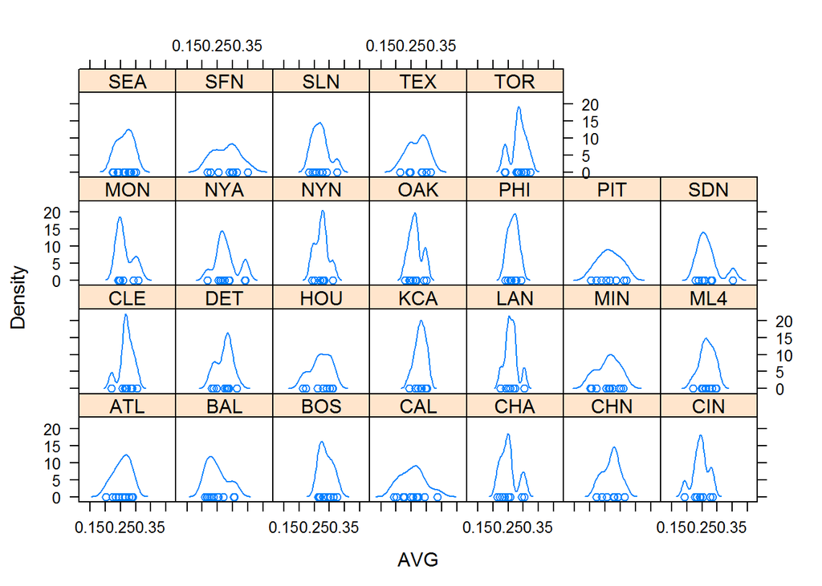

```r
res <- dbSendQuery(con, "select * from batting where yearID=1984 and AB > 250");
batting1985<-fetch(res, n=-1);
attach(batting1985);
AVG<-H/AB;##compute Batting Avg using hits and at bats
densityplot(~AVG|teamID, plot.points=TRUE)##plot avg by team using lattice
```

### Bonus Round: Sneak preview of the pitchRx package

Much thanks to the open source help provided by Carson Sievert. Please [see his website](http://cpsievert.github.io/pitchRx/) for further documentation.

```r
library(pitchRx)
library(plyr)
library(dplyr)
library(RSQLite)
library(ggplot2)
library(viridis)
```

```r
june19 <- scrape(start = "2015-06-19", end = "2015-06-19")#scrapes pitchFX
pitches <- plyr::join(june19$pitch, june19$atbat,
                     by = c("num", "url"), type = "inner") ##uses plyr to join data into more readable format
```

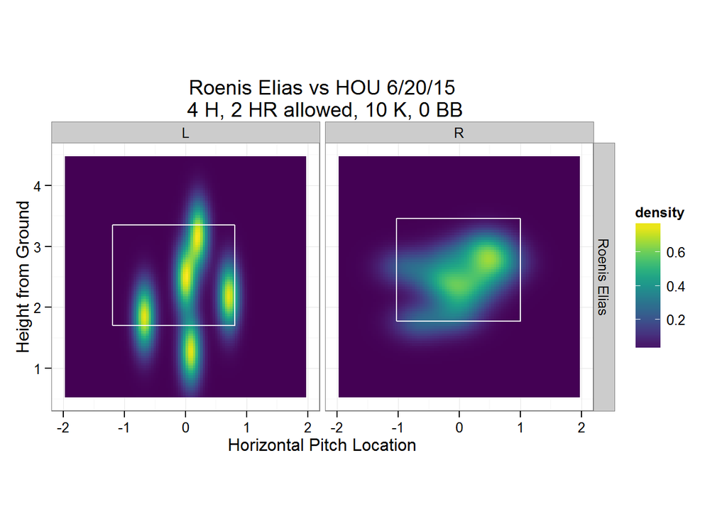

```r
##specify the pitcher you are interested in
elias = subset(pitches, pitcher_name == "Roenis Elias")

# convert characters to numbers
elias$px = as.numeric(elias$px)
elias$pz = as.numeric(elias$pz)
elias$start_speed = as.numeric(elias$start_speed)

strikes <- subset(elias, des == "Called Strike")
strikeFX(strikes, geom = "tile") +
  facet_grid(pitcher_name ~ stand) +
  coord_equal() +
  theme_bw() +
  viridis::scale_fill_viridis() +
  labs(title = "Roenis Elias vs HOU 6/20/15
 4 H, 2 HR allowed, 10 K, 0 BB")
```

Neat. We can see from this density plot that, when Roenis Elias dominated the Houston Astros, he pitched to much different locations against left-handed batters versus right-handed batters. Perhaps we would want to load more games to make visualizations comparing Elias across games. I will not go that far in this turotial. But, if you want to load more than a few games, you will likely have to store the result in a local SQLite database. This call will locally store every pitch thrown in the MLB from 2012 onward. Note: This will take a while to load onto your machine if you specify more than a few weeks of data.

```r
db <- src_sqlite("pitchfx.sqlite3", create = T)
scrape(start = "2012-01-01", end = Sys.Date(), connect = db$con)
```

Thank you for reading! Please email me at Ian.Ruginski@utah.edu if you have any questions or suggestions. I plan to add more tutorials in the future using RMarkdown covering statistical and visualization techniques using R.